# Installation of dndscv. Detecting selection in tumours and normal tissue

Federico Abascal

29/09/2019

The **dndscv** repository can be found at [link](https://github.com/im3sanger/dndscv). There can be found some other tutorials.

### Installing dndscv

> library(devtools); install_github(“im3sanger/dndscv”)

Installing **dndscv** for the first time may take some time as it will install all other dependencies (GenomicRanges, IRanges, Rsamtools, MASS, seqinr, Biostrings packages). Besides, it may be necessary for you to install **devtools** if you haven’t used it before.

### Detecting selection in esophageal carcinoma (TCGA data)

For this analysis we will use TCGA exome data for 177 esophageal carcinoma tumours.

```r
library("dndscv")
```

### Load the mutation data

We will use the file **esophagealCarc-tcga.tsv**, which contains the mutations found in these patients.

Save this file in a folder of your computer and set R’s working directory accordingly

```r
working_directory = "/Users/fa8/Documents/Presentaciones/Romania/tutorial_and_mutation_datasets"
setwd(working_directory)
mutations = read.table("esophagealCarc-tcga.tsv",sep="\t",stringsAsFactors=F,header=T)
```

It’s always good to have a look at the data before doing any analysis. Number of mutations and samples

```r
nrow(mutations)
```

```
## [1] 26958
```

```r
length(unique(mutations$sampleID))
```

```
## [1] 177
```

Histogram of number of mutations per sample

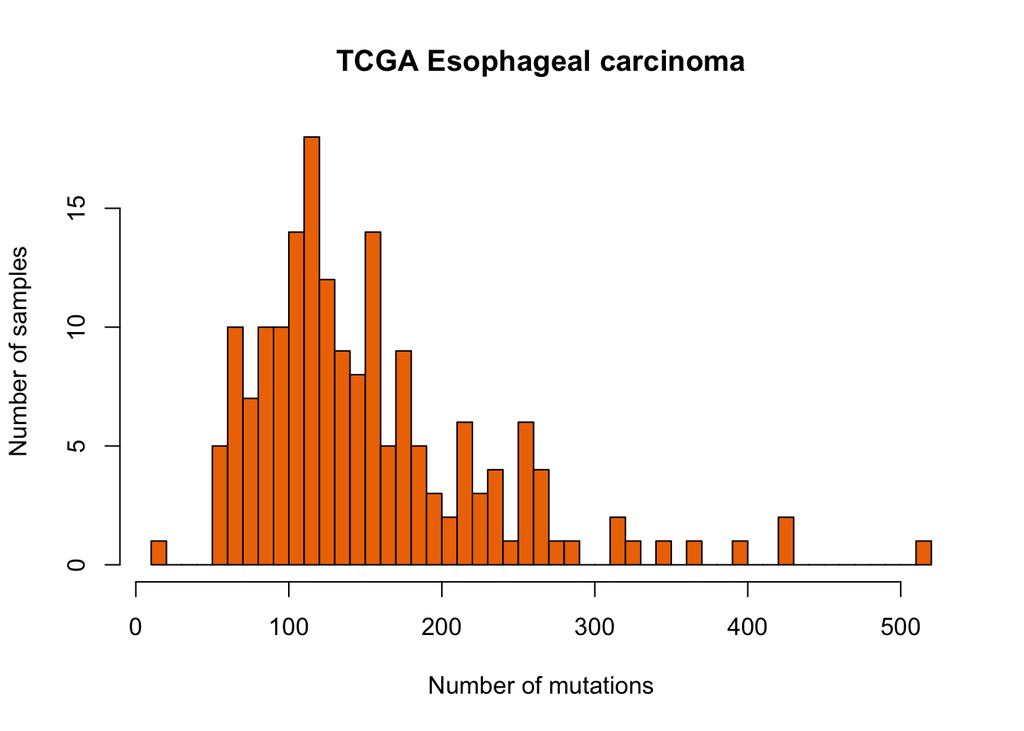

```r
hist(table(mutations$sampleID),main="TCGA Esophageal carcinoma",xlab="Number of mutations",ylab="Number of samples",breaks=50,col="darkorange2")
```

The histogram shows there are no hypermutators in this dataset (samples with > 1000 coding mutations). This is because I removed them before hand (hypermutators can be problematic for different reasons).

### Run dndscv selection analyses

Let’s run **dndscv**. It will take a few minutes.

```r
dnds_tcga = dndscv(mutations)
```

The output is a **list** and contains the following fields:

```r
class(dnds_tcga)
```

```
## [1] "list"
```

```r
names(dnds_tcga)
```

```
##  [1] "globaldnds"   "sel_cv"       "sel_loc"      "annotmuts"
##  [5] "genemuts"     "mle_submodel" "exclsamples"  "exclmuts"
##  [9] "nbreg"        "nbregind"     "poissmodel"   "wrongmuts"
```

The fields of most interest are:

- **globaldnds**: global dN/dS estimate across all genes
- **sel_cv**: dN/dS estimates for each gene using the dNdScv model
- **sel_loc**: dN/dS estimates for each gene using the dNdSloc model (no covariates)
- **annotmuts**: annotated mutations including functional impact, genes…
- **genemuts**: observed and expected numbers of mutations per gene
- **mle_submodel**: the substitution model

Let’s have a look at the annotated mutations

```r
head(dnds_tcga$annotmuts)
```

```
##       sampleID chr      pos ref mut    gene strand ref_cod mut_cod
## 1 TCGA-2H-A9GF   1 27057972   C   A  ARID1A      1       C       A
## 2 TCGA-2H-A9GF   1 34663145   G   A C1orf94      1       G       A
## 3 TCGA-2H-A9GF   1 35657099   C   T    SFPQ     -1       G       A
## 4 TCGA-2H-A9GF   1 36291296   C   T    AGO4      1       C       T
## 5 TCGA-2H-A9GF   1 44137514   G   A   KDM4A      1       G       A
## 6 TCGA-2H-A9GF   1 49052820   G   A   AGBL4     -1       C       T
##   ref3_cod mut3_cod aachange ntchange codonsub   impact             pid
## 1      ACC      AAC    Y560*   C1680A  TAC>TAA Nonsense ENSP00000320485
## 2      CGC      CAC    A214T    G640A  GCC>ACC Missense ENSP00000435634
## 3      AGG      AAG    R287K    G860A  AGG>AAG Missense ENSP00000349748
## 4      CCG      CTG    R169C    C505T  CGT>TGT Missense ENSP00000362306
## 5      CGC      CAC    A568T   G1702A  GCT>ACT Missense ENSP00000361473
## 6      CCG      CTG    R375W   C1123T  CGG>TGG Missense ENSP00000360905
```

Distribution of functional impacts:

```r
table(dnds_tcga$annotmuts$impact)
```

```
##
## Essential_Splice         Missense           no-SNV         Nonsense
##              339            17807             1005             1153
##        Stop_loss       Synonymous
##               24             6630
```

Mutations in a specific gene, e.g. *ARID1A*:

```r
dnds_tcga$annotmuts[which(dnds_tcga$annotmuts$gene=="ARID1A"),]
```

```
##           sampleID chr      pos ref mut   gene strand ref_cod mut_cod
## 1     TCGA-2H-A9GF   1 27057972   C   A ARID1A      1       C       A
## 1823  TCGA-2H-A9GR   1 27100324   C   T ARID1A      1       C       T
## 4831  TCGA-IG-A8O2   1 27101359   C   T ARID1A      1       C       T
## 5351  TCGA-JY-A6FA   1 27088764   C   A ARID1A      1       C       A
## 6377  TCGA-JY-A939   1 27106648   G   A ARID1A      1       G       A
## 6883  TCGA-JY-A93F   1 27097621   -   A ARID1A      1       .       .
## 7682  TCGA-L5-A4OE   1 27057934   C   T ARID1A      1       C       T
## 8452  TCGA-L5-A4OJ   1 27101252   C   T ARID1A      1       C       T
## 10294 TCGA-L5-A4OX   1 27106970   -   C ARID1A      1       .       .
## 11179 TCGA-L5-A88Z   1 27106916   A   - ARID1A      1       .       .
## 13006 TCGA-L5-A8NL   1 27087417   C   - ARID1A      1       .       .
## 15195 TCGA-LN-A49M   1 27087879   C   T ARID1A      1       C       T
## 20466 TCGA-R6-A6DQ   1 27057668   C   T ARID1A      1       C       T
## 22153 TCGA-RE-A7BO   1 27089531   -   G ARID1A      1       .       .
```

[output cut: 30 more lines]

Gene summary and expected counts:

```r
dnds_tcga$genemuts[which(dnds_tcga$genemuts$gene_name=="ARID1A"),]
```

```
##      gene_name n_syn n_mis n_non n_spl  exp_syn  exp_mis   exp_non
## 1465    ARID1A     2     3     4     0 1.420574 3.386366 0.2040143
##         exp_spl exp_syn_cv
## 1465 0.04598905  0.8877278
```

It turns out *ARID1A* has 4 stop codon mutations in this dataset while the expected number is 0.2040143. *Is it under selection?*

The answer can be found in the table **sel_cv**. This table contains the main results of **dndscv**, with estimates of the statistical significance of selection for each gene.

Let’s look at the 20 most significant genes:

```r
print(dnds_tcga$sel_cv[1:20,],digits=3)
```

```
##             gene_name n_syn n_mis n_non n_spl n_ind wmis_cv wnon_cv
## 18057            TP53     0   101    29    13    27 189.541   821.5
## 3523  CDKN2A.p16INK4a     0     6     0     3     4  20.244   206.3
## 11333          NFE2L2     0    15     0     0     2  32.936     0.0
## 16238           SMAD4     0     6     6     0     1  13.942   134.2
## 19947          ZNF750     0     3     3     0     6   4.160    71.0
## 12977          PIK3CA     0    17     0     0     0  18.585     0.0
## 6426            FBXW7     0     4     2     0     4   7.400    30.6
## 9207            KMT2D     3     7     5     1     7   1.261    13.3
## 1465           ARID1A     2     3     4     0     5   1.390    25.1
## 11521          NOTCH1     2     7     1     1     5   3.151    14.8
## 10912            MUC6     2     2     0     0     7   0.615     0.0
## 6385           FBXO15     0     5     0     0     3   6.960     0.0
## 13865           PTCH1     0     0     2     1     2   0.000    34.7
## 8719              IVL     1    13     0     0     0  12.482     0.0
```

[output cut: 48 more lines]

There are 10 genes with evidence of positive selection, one of which is *ARID1A*, which is significant thanks to 4 stop codons and 5 indels (frame-shifting).

For an easier display:

```r
print(dnds_tcga$sel_cv[which(dnds_tcga$sel_cv$gene=="ARID1A"),],digits=3)
```

```
##      gene_name n_syn n_mis n_non n_spl n_ind wmis_cv wnon_cv wspl_cv
## 1465    ARID1A     2     3     4     0     5    1.39    25.1    25.1
##      wind_cv pmis_cv ptrunc_cv pallsubs_cv  pind_cv qmis_cv qtrunc_cv
## 1465    24.2   0.649  6.16e-05    0.000316 8.95e-05   0.786     0.155
##      qallsubs_cv pglobal_cv qglobal_cv
## 1465       0.326   5.21e-07    0.00116
```

There are some cancer-drivers with q-values close to significance, like: *PTEN* or *RB1*. To gain more power to detect cancer drivers we can do restricted hypothesis testing on a set of cancer genes. One way of accomplishing this is by applying multiple hypothesis correction ourselves.

Here is how to do this for 70 cancer genes. Larger lists of cancer genes can be used, but I am using this reduced list for practical reasons.

```r
drivers = read.table("esophagous_healthy-sanger.genes_in_panel.tsv",header=F)[,1]
drivers_sel_cv = dnds_tcga$sel_cv[which(dnds_tcga$sel_cv$gene %in% drivers),]
drivers_sel_cv$qglobal_rht = p.adjust(drivers_sel_cv$pglobal_cv,method="BH")
print(drivers_sel_cv[1:20,],digits=3)
```

```
##       gene_name n_syn n_mis n_non n_spl n_ind wmis_cv wnon_cv wspl_cv
## 18057      TP53     0   101    29    13    27 189.541  821.48  821.48
## 11333    NFE2L2     0    15     0     0     2  32.936    0.00    0.00
## 16238     SMAD4     0     6     6     0     1  13.942  134.21  134.21
## 12977    PIK3CA     0    17     0     0     0  18.585    0.00    0.00
## 6426      FBXW7     0     4     2     0     4   7.400   30.64   30.64
## 1465     ARID1A     2     3     4     0     5   1.390   25.11   25.11
## 11521    NOTCH1     2     7     1     1     5   3.151   14.83   14.83
## 13865     PTCH1     0     0     2     1     2   0.000   34.74   34.74
## 13874      PTEN     0     2     2     0     2   5.322   49.83   49.83
## 14249       RB1     0     0     2     0     2   0.000   16.64   16.64
## 11664      NSD1     0     3     3     1     1   1.310   19.31   19.31
## 5815      ERBB2     1     7     1     0     1   5.835    8.66    8.66
## 15257     SALL1     1    11     0     0     0   6.002    0.00    0.00
## 3015      CASP8     0     3     0     0     1   7.163    0.00    0.00
```

[output cut: 48 more lines]

We can see how *PTEN* and other cancer genes are now significant.

### How many *driver* mutations per patient?

One key question in cancer is how many driver mutation are needed to develop a tumour. An estimation can be obtained using the **globaldnds** results.

```r
print(dnds_tcga$globaldnds,digits=3)
```

```
##      name   mle cilow cihigh
## wmis wmis 1.057 1.026   1.09
## wnon wnon 1.133 1.059   1.21
## wspl wspl 0.705 0.629   0.79
## wtru wtru 0.993 0.935   1.05
## wall wall 1.055 1.024   1.09
```

The dN/dS for missense mutations (wmis) is 1.057, significantly higher than 1 (conf. interval 1.026-1.09), indicating there is evidence of positive selection. Since different analyses suggest that negative selection is mostly absent in tumours (see Martincorena et al, *Cell* 2017), the global dN/dS can be used to estimate how many driver mutations are there.

These are the mutation impacts in the dataset:

```r
table(dnds_tcga$annotmuts$impact)
```

```
##
## Essential_Splice         Missense           no-SNV         Nonsense
##              339            17807             1005             1153
##        Stop_loss       Synonymous
##               24             6630
```

Since wmis is 1.057, about 5% of the missense mutations are in excess (*being in excess* is equivalent to saying they are *drivers* or have been *positively selected*). To calculate the number of driver mutations we can use the following formula:

N_drivers = ( wmis - 1 ) / wmis * N_missense

for the data at hand:

```r
num_drivers =  (dnds_tcga$globaldnds["wmis","mle"] - 1) / dnds_tcga$globaldnds["wmis","mle"] * (table(dnds_tcga$annotmuts$impact)["Missense"])
conf_intervals =  (dnds_tcga$globaldnds["wmis",c("cilow","cihigh")] - 1) / dnds_tcga$globaldnds["wmis",c("cilow","cihigh")] * (table(dnds_tcga$annotmuts$impact)["Missense"])
cat("There are",num_drivers, " driver missense mutations\n")
```

```
## There are 966.3001  driver missense mutations
```

How many drivers per sample on average? Since there are 177 samples, this means that on average each sample would carry about 5-6 driver missense mutations.

```r
num_drivers_per_sample = c(num_drivers) / length(unique(dnds_tcga$annotmuts$sampleID))
num_drivers_per_sample_conf_intervals = as.vector(conf_intervals) / length(unique(dnds_tcga$annotmuts$sampleID))
cat("The estimated number of driver missense mutations per sample is ",round(num_drivers_per_sample,2), " [CI95: ",round(num_drivers_per_sample_conf_intervals[1,1],2),"-",round(num_drivers_per_sample_conf_intervals[1,2],2),"]\n",sep="")
```

```
## The estimated number of driver missense mutations per sample is 5.46 [CI95: 2.57-8.27]
```

### Detecting selection in healthy oesophagus (Martincorena *et al*, 2018)

Esophageal tumours (and all tumours) show the footprint of positive selection in the form of mutation of oncogenes and tumour suppressors. This is well known and expected. But what about healthy esophagous? We will explore the data from *Somatic mutant clones colonize the human esophagus with age* (Martincorena et al, *Science* 2018).

The mutation data comes from multiple mini-biopsies of healthy oesophagous. They have been deeply sequenced for a panel of 70 cancer genes (listed in “esophagous_healthy-sanger.genes_in_panel.tsv”). The mutation data is available in the file “esophagous_healthy-sanger.tsv”.

Load mutations:

```r
mutations = read.table("esophagous_healthy-sanger.tsv",sep="\t",stringsAsFactors=F,header=T)
```

It’s always good to have a look at the data before doing any analysis. Number of mutations and samples

```r
nrow(mutations)
```

```
## [1] 8994
```

```r
length(unique(mutations$sampleID))
```

```
## [1] 835
```

Histogram of number of mutations per sample

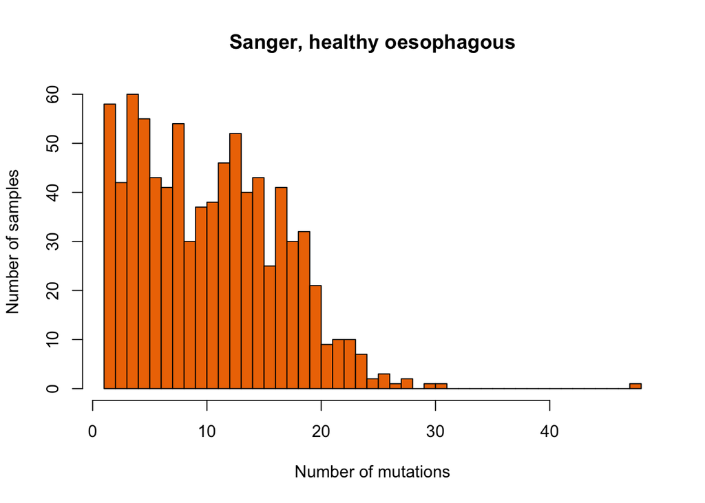

```r
hist(table(mutations$sampleID),main="Sanger, healthy oesophagous",xlab="Number of mutations",ylab="Number of samples",breaks=50,col="darkorange2")
```

##### Is there any evidence of positive selection?

Load the list of genes in the panel to restrict the dndscv analysis to them:

```r
drivers = read.table("esophagous_healthy-sanger.genes_in_panel.tsv",header=F)[,1]
```

Run dndscv:

```r
dnds_healthy = dndscv(mutations,gene_list=drivers)
```

These are the counts of functional impacts:

```r
table(dnds_healthy$annotmuts$impact)
```

```
##
## Essential_Splice         Missense           no-SNV         Nonsense
##              330             3505             1665              871
##        Stop_loss       Synonymous
##                4              600
```

It seems there is an excess of non-synonymous mutations!

Let’s look at the global dN/dS:

```r
print(dnds_healthy$globaldnds,digits=3)
```

```
##      name  mle cilow cihigh
## wmis wmis 2.24  2.05   2.45
## wnon wnon 9.44  8.38  10.63
## wspl wspl 8.79  7.53  10.27
## wtru wtru 9.23  8.29  10.28
## wall wall 2.81  2.57   3.06
```

There is indeed such an excess. It seems more than half of the missense mutations have been positively selected. And almost 90% of the nonsense mutations!

##### Which genes are under positive selection?

```r
print(dnds_healthy$sel_cv[1:20,],digits=3)
```

```
##    gene_name n_syn n_mis n_non n_spl n_ind wmis_cv wnon_cv wspl_cv wind_cv
## 69      TP53     9   550    70    51    88  44.385   99.13   99.13  64.878
## 44    NOTCH1    24   703   302   125   422  14.022  114.55  114.55  47.958
## 45    NOTCH2    12   261    63    29   122   7.085   34.09   34.09  14.336
## 46    NOTCH3    12   163   105    43    80   5.358   69.10   69.10  10.008
## 26      FAT1    21   143   142    16   162   2.684   44.93   44.93  10.254
## 7     ARID1A     8    35    42     6    68   1.680   31.73   31.73   8.641
## 3      AJUBA     1    22    10     0    30   4.080   24.85   24.85  16.167
## 18      CUL3    10    36    10    13    20   1.856   11.44   11.44   7.555
## 12     CCND1     2    15    14     0     1   3.462   35.19   35.19   0.981
## 51    PIK3CA     2    74     2     0     4   7.857    1.83    1.83   1.087
## 8      ARID2    13    30    13     2    12   0.936    5.48    5.48   1.899
## 43    NFE2L2     5    31     1     0     8   3.253    1.30    1.30   3.835
## 21     EPHA2     7    21     4     6     5   1.385    7.35    7.35   1.487
## 70      TP63     7    32     5     2     6   2.278    5.33    5.33   2.559
```

[output cut: 48 more lines]

This tells us that in healthy oesophagous there are lots of positively selected mutations in *TP53*, *NOTCH1*, *NOTCH2*, *NOTCH3*, *FAT1*, *ARID1A* and other genes.

To read more about this study: https://science.sciencemag.org/content/362/6417/911+